# About

This tool generates additional outputs beyond just BCG results:

- Hundreds of metrics
- Summaries of fish age class categories

If you are using the BCG results, your data should be collected and processed using these field and laboratory protocols [[PDF](https://github.com/Blocktt/LowerBoiseBCGCalc/blob/main/inst/apps/LowerBoiseBCGCalc/www/links/Methods_Bugs_Fish_20260525.pdf)]:

- Macroinvertebrates: USGS National Water‑Quality Assessment (NAWQA) Richest Targeted Habitat (RTH) method
- Fish: composite of two electrofishing passes - one through deep-water areas with a boat or tow barge; the second through shallower riffle areas with a backpack electrofisher

If you used different methods, the BCG results should be interpreted with caution because they are outside the experience of the model.

# Quick Tutorial

Here is a short user guide [[PDF]](https://github.com/Blocktt/LowerBoiseBCGCalc/blob/main/inst/apps/LowerBoiseBCGCalc/www/links/QuickTutorial_LBR_20260807.pdf).

**Test Files**:

- Fish [[CSV]](https://github.com/Blocktt/LowerBoiseBCGCalc/blob/main/inst/apps/LowerBoiseBCGCalc/www/links/LBR_Fish_Input_20260707.csv)
- Bugs [[CSV]](https://github.com/Blocktt/LowerBoiseBCGCalc/blob/main/inst/apps/LowerBoiseBCGCalc/www/links/LBR_Bug_Input_20260707.csv)

For those who prefer to use R instead of this online calculator, the functions are carried out by the BCGcalc and [BioMonTools](https://cran.r-project.org/web/packages/BioMonTools/index.html) R packages, which are available on GitHub and were developed by Erik W. Leppo from Tetra Tech (Erik.Leppo@tetratech.com).

*If using the R code instead of the Shiny app, you won’t need internet access if you have R installed on your computer and have downloaded all the necessary packages.

## What is the Biological Condition Gradient?

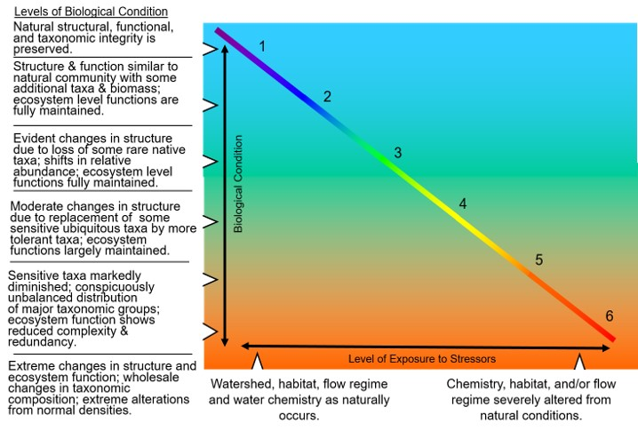

The Biological Condition Gradient (BCG) model is a conceptual model describing how ecological attributes change in response to increasing levels of human-caused stress. The BCG has a universal scoring scale with six levels of biological condition, ranging from observable biological conditions found at no or low levels of stressors (level 1) to those found at high levels of stressors (level 6). Narratives for each BCG level are shown in the figure above. The model is calibrated using expert elicitation. Biologists work collaboratively to reach consensus on assigning biological samples to BCG levels. Their ratings and rationale are then used to calibrate a quantitative model. Model performance is judged based on how well the model matches the expert BCG level assignments.

## Additional resources

Synopsis: [The Biological Condition Gradient (BCG) - A Model for Interpreting Anthropogenic Stress on the Aquatic Environment](https://www.epa.gov/sites/default/files/2021-03/documents/bcg-flyer-2021.pdf)

[A Practitioner’s Guide to the Biological Condition Gradient: A Framework to Describe Incremental Change in Aquatic Ecosystems](https://www.epa.gov/sites/default/files/2016-02/documents/bcg-practioners-guide-report.pdf)

*Last updated 2026-08-07*